# Arduino for Neurobiologists: Data Logging

Joe Negri

An important element necessary to implement the use of Arduino based devices for research purposes is ‘*data-logging*’. Data-logging is simply a means of recording the measurements made by the instrument in a permenant file structure to allow for later access for analysis and visualization.

For most instruments connected to a computer with dedicated acquisition software, data-logging is trivial. However, given the minimalist nature of the AVR chips incorporated in Arduinos which are executing a single C program, data-logging functionality must be deliberately included as part of the programming.

As discussed previously in this workshop, Arduinos can provide messages about the current states or conditions of peripherals by *speaking* over serial communication. Therefore, methods for data-logging with Arduino will involve programming the Arduino to provide these types of messages and estabishing a means of saving them somewhere.

Data-logging for Arduinos can be thought of as falling into one of three modalities

- Wired connection
  - Arduino is directly connected to computer and writes to file on hard drive
- Disconnected
  - Arduino is disconnected and writes to memory storage built into the device
- Wireless connection
  - Arduino uses radio based communication (e.g. WiFi) capabilites built into the device to write to memory on a remote computer hard drive

The data to be logged will typically include:

- the data itself: sensor readings, status messages, etc.
- a timestamp to indicate when the event happened

The destination for the data-logging will typically be a flat text file such as a `.csv` or a file allocation table (e.g. FAT32 or other) within Flash memory.

### Having Arduino tell the time

Before proceeding to the different modalites for data-logging, let’s first address the element universal to all methods, tracking time.

Built-in functions such as `millis()` will return the number milliseconds elapsed since the program started. However, this is a relative time measurement. Everytime the program restarts, such as when the device is disconnected and reconnected to power, the clock restarts. For data collection purposes, it is much more useful to have absolute time measurement in relavent units (e.g. *Year-Month-Day_Hour:Minute:Seconds*). Having absolute time measurements is important to avoid ambiguity in the chronology of events being recorded. In order to have the Arduino report absolute time, the program must include a means of setting the time. This is an important consideration to keep in mind for any timekeeping process using Arduino. While the Arduino hardware is capable of tracking elapsed time, the device as now idea what time it is without being told. In this sense an Arduino can be thought of like a digital clock the restarts at 12:00AM following a power outage, the elapsed time since the outage is correct but the absolute time is incorrect. For time units, the AVR micro-controllers within the Arduino that operate at mega-hetz (MHz) speeds peforming millions of opertions a second, milliseconds are a relavant even *long* time interval, these units are much less practical for data reporting purposes where more intuitively *human-level* time scales of seconds, minutes, hours, *etc* are preferable.

A useful tool for addressing these time reporting challenges is Paul Stoffregen’s Time library for Arduino. This library contains functions to calculate values of seconds, minutes, hours *etc* as well as functions for setting the time.

> *Note: While the Arduino IDE includes the original version of the Time library, the link above is directed to an updated version of the library that is compatable with newer versions of the IDE and more recently developed Arduino boards*

In order use these functions when programming the Arduino, the library must be placed in a directory that is searched when the program is being compiled. The default directory for storing Arduino libraries on mac OS is `~/Documents/Arduino/libraries/`. Placing the folder downloaded from the linked GitHub site will allow for including the associated header files in sketches.

Below is an example sketch (with minor modifications) provided with the Time library. This sketch will set the time on the Arduino by informing of the current time by communicating over serial. Once the time is set, the Arduino will report the current time every second. After flashing this code to the Arduino and opening the serial monitor, the message `Waiting for sync message`. The time is set by sending a message “T” followed by the 10-digit POSIX time (e.g. T1543171333). POSIX time (or UNIX time) is a common timekeeping protocol used for computers and operating systems, and represents the number of seconds that have passed since January 1st 1970. The current POSIX time can be obtain on Linux or mac systems by entering `date +%s` on the command line (Terminal on macOS), or it can be found [here](https://time.is/Unix_time_now)

```cpp
/*
 * TimeSerial.pde
 * example code illustrating Time library set through serial port messages.
 *
 * Messages consist of the letter T followed by ten digit time (as seconds since Jan 1 1970)
 * you can send the text on the next line using Serial Monitor to set the clock to noon Jan 1 2013
 T1357041600
 *
 * A Processing example sketch to automatically send the messages is included in the download
 * On Linux, you can use "date +T%s\n > /dev/ttyACM0" (UTC time zone)
 */

//-----Preamble-----//
#include <TimeLib.h>

#define TIME_HEADER  "T"   // Header tag for serial time sync message
#define TIME_REQUEST  7    // ASCII bell character requests a time sync message

//-----Functions-----//

// digital clock display of the time
void digitalClockDisplay(){
  Serial.print(hour());
  printDigits(minute());
  printDigits(second());
  Serial.print(" ");
  Serial.print(day());
  Serial.print(" ");
  Serial.print(month());
  Serial.print(" ");
  Serial.print(year());
  Serial.println();
}

// utility function for digital clock display: prints preceding colon and leading 0
void printDigits(int digits){
  Serial.print(":");
  if(digits < 10)
    Serial.print('0');
  Serial.print(digits);
}

// process serial message with current time, sent as "T" followed by 10-digit POSIX time
void processSyncMessage() {
  unsigned long pctime;
  const unsigned long DEFAULT_TIME = 1357041600; // Jan 1 2013

  if(Serial.find(TIME_HEADER)) {
     pctime = Serial.parseInt();
    //check the integer is a valid time (after Jan 1 2013)
     if( pctime >= DEFAULT_TIME) {
       // Sync Arduino clock to the time received on the serial port
       setTime(pctime);
     }
  }
}

time_t requestSync()
{
  Serial.write(TIME_REQUEST);
  return 0; // the time will be sent later in response to serial mesg
}

//-----Setup-----//

void setup()  {
  Serial.begin(9600);
  while (!Serial) ; // Needed for Arduino Leonardo only
  pinMode(13, OUTPUT);
  setSyncProvider( requestSync);  //set function to call when sync required
  Serial.println("Waiting for sync message");
}


//-----Main-----//

void loop(){
  if (Serial.available()) {
    processSyncMessage();
  }
  if (timeStatus()!= timeNotSet) {
    digitalClockDisplay();
  }
  if (timeStatus() == timeSet) {
    digitalWrite(13, HIGH); // LED on if synced
  } else {
    digitalWrite(13, LOW);  // LED off if needs refresh
  }
  delay(1000);
}
```

### Data-logging over wired connection

*Recording data while Arduino is physically connected to computer*

As mentioned above, the basic method for communicating with the micro-controller on the Arduino is through serial communication. Data-logging is merely an extension of this exercise to store the messages sent from the Arduino in a permanent file.

Software that allows for a user to communicate in this fashion are referred to as terminal emulators (or terminals). This harkens back to the days of main frame computing when a person would use a terminal to communicate to the computer.

The Arduino IDE includes a terminal called Serial Monitor that displays incoming serial messages and allows the user to sent messages to the Arduino while the two are connected via a USB cable. Unfortunately, Serial Monitor does not include functionality to save these messages. Once the window is closed, the communications are lost. Therefore, while Serial Monitor is useful for real-time monitoring and debugging is not a viable option for data-logging.

Fortunately, there are other tools available.

#### CoolTerm

*a more user friendly option*

CoolTerm is a free terminal emulator developed by Roger Meier. It has a graphical interface making it more user friendly than GNU-screen, and it has more features including data-logging, than the Serial Monitor within the Arduino IDE. CoolTerm is available [here](http://freeware.the-meiers.org/) with versions for mac OS, Windows, and Linux systems.

Once CoolTerm is installed the serial connection to the Arduino can be established by going to the *Connection* menu within CoolTerm and choosing *Options*, or instead using the `Cmd+I` keyboard short cut.

[figure not shown]

Within the *Options* specify the settings for the serial port connected to the Arduino. Other than selecting the Port and the confirming that the baud rate is set to 9600, all other settings can be left as defaults.

[figure not shown]

The connection then needs to be initiated by selecting the *Connect* icon from the menu bar, or using the `Cmd+K` shortcut.

To send a message to the Arduino, select the *Send String* option under the *Connection* menu or use the `Cmd+T` shortcut.

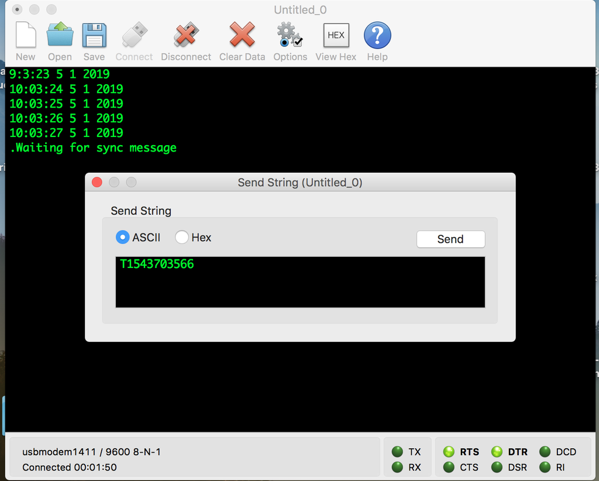

Lastly, to log the messages being send from the Arduino choose the *Capture Textfile* option under the *Connection* menu or use the `Cmd+R` and specify the name and location of the text file to write to. That’s it! The other good thing to know is that as long as the port is active, the data will continue to log, even if the computer is sleeping (e.g. the laptop is closed but not shutdown).

#### GNU-screen

*a bare-bones option*

‘screen’ is a GNU free software package that can be utilized as serial terminal. This option is best suited to individuals who are already comfortable working with command line software and will be easiest to implement on Linux and mac OS platforms since screen is already installed. Windows users will need to first install [Cygwin](https://www.cygwin.com/), a utility for using Linux software on Windows.

> *Note for Windows users: Cygwin affords the use of many useful tools beyond GNU-screen and is worth installing, especially for those individuals interested in exploring AVR micro-controller programming beyond the Arduino platform.*

Data-logging with screen essentially boils down to establishing a serial monitoring session and creating a log file of that session.

In order to establish the serial monitoring session, you will need to tell screen which serial port the Arduino is connected to. This can be done by entering the following on the command line (Terminal on macOS).

`ls /dev/tty.*`

The serial port hosting the Arduino will likely look something like this: `/dev/tty.usbmodem1411` although the tailing numbers could differ.

Before trying to log data, try out screen as a serial monitor. Using the Arduino IDE flash a program to the device the is passing a message over serial (i.e. the script contains the function `Serial.print("some message")`). Initiate screen as a serial monitor by entering the command:

`screen /dev/tty.usbmodem1411 9600`

The first argument is the serial port the Arduino is connected to and the second is the baud rate of the serial communication. Within a couple seconds the appearance of the window should change and the message being sent from the Arduino should begin appearing on the screen.

To quit screen type `Cntrl-a` followed by `Cntrl-\`

In order to start data-logging with screen, you simply need to tell screen to create a log file when initiating the session. Using screen verison 4.6.2 (or later) is preferrable, since beginning with this version it is possible to specify the name of the log file. You can check the version of screen installed by entering the command `screen -version`. The latest version of screen is available [here](https://www.gnu.org/software/screen/). Mac users should consider installing [Homebrew](https://brew.sh/), which itself will install the latest verion of screen. Those mac users with Homebrew already installed can update to the latest version of screen by entering the command: `brew install screen`.

Now to begin data-logging, reinitiate screen this time including the options `-L` to create the log file and `-Logfile <path-to-file>` to specify the name of the log file. For instance:

`screen -L -Logfile ~/Desktop/test/screenLogfileTest.csv /dev/tty.usbmodem1411 9600`

> *Note: It is still possible to generate log files using earlier version of screen (pre v4.6.2) by invoking the* `-L` *option. However, it is not possible to specify the name of the log file. Instead the log file will have the name* `screenlog.n` *where n is the instance of screen, usually 0.*

GNU-screen offers a quick way to start data-logging with Arduino, especially for Linux and macOS users for whom it is already available. However, its functionality is fairly low-level and not particularly user friendly. For instance, while it is possible to send messages to the Arduino from within the screen session there is no separate ‘send’ window as there is in Serial Monitor. Commands are typed in, but no feedback is provided as to what has been typed. Having to send commands blindly is difficult for any kind of complex command, such as a 10-digit number used in the example above.

#### R

*because R is awesome*

In the first two options discussed above (GNU-screen and CoolTerm) the data-logging strategy employs a terminal emulator to capture the serial messages originating from the Arduino and storing them within a log file on the computer. An alternative strategy is to run a program on the computer that periodically checks the serial port and stores the most recent message within its own data structure. This later approach can be implemented using R, Python, or MatLab (plus numerous other programs).

The advantages to this approach are: *i* it minimizes what need to be done on the Arduino end; *ii* in addition to data-logging, the other analytical and graphical capabilites of these programs can be readily applied to the data.

In the terminal emulator approaches all the necessary information, including time, had to be provided within the incoming message from the Arduino, since the terminal emulators were simply caching the messages to a log file on the computer hard-drive. For this approach, it is best to keep the incoming message from Arduino to be simply the sensor reading (or other data to be logged) and allow the program with access the computer operating system to hand the timekeeping.

Below is an example Arduino sketch that once a second will pass a random number between 1 - 100 over serial.

```cpp
//-----Preamble-----//

long randNumber;
long msecCount = 0;
long interval = 1000;

//-----Setup-----//
void setup() {
  Serial.begin(9600);
  randomSeed(analogRead(0));
  OCR0A = 0xAF;
  TIMSK0 |= _BV(OCIE0A);
}

// Interrupt is called once a millisecond, adds 1 to msecCount
SIGNAL(TIMER0_COMPA_vect)
{
  msecCount++;
}

//-----Main-----//

void loop() {
  if(msecCount > interval){
    randNumber = random(1,100);
    Serial.println(randNumber);
    msecCount = 0;
    delay(10);
    }
  }
```

The following is an example in base R that will check the messages coming into the serial port connected to the Arduino and will write the data to a csv file within a directory “test” on the Desktop (*NB: this is using mac OS file paths*). This example expands on a method suggested by Markus Gesman on his [blog](https://magesblog.com/), which is worth checking out for anyone interested in using R with electronics and/or data visualization.

```r
arduinoPort <- "/dev/cu.usbmodem1411" #CU (check up) port to monitor
recDuration <- 30 #number of seconds to monitor serial port
recInterval <- 2 # number of seconds between recording observations
dataFile <- "~/Desktop/test/RserialMonitorTest.csv" # file to place recorded data

endTime <- Sys.time()+recDuration

# connection to monitor
arduinoCon <-
  file(arduinoPort, open = "r")

# dataframe to store readings
readingDF <- data.frame()

while(Sys.time()<endTime){
  readingRow <- cbind.data.frame(
    Sys.time(),
    scan(arduinoCon, n=1)
  )
  readingDF <- rbind.data.frame(
    readingDF,
    readingRow
  )
  Sys.sleep(recInterval)
}

colnames(readingDF) <- c("time","reading")

close(arduinoCon)

write.csv(
  readingDF,
  dataFile,
  row.names = FALSE
)
```